# Biostat 203B Homework 5

Due Mar 22 @ 11:59PM

Author

Li Zhang 206305918

## Predicting ICU duration

Using the ICU cohort `mimiciv_icu_cohort.rds` you built in Homework 4, develop at least three machine learning approaches (logistic regression with enet regularization, random forest, boosting, SVM, MLP, etc) plus a model stacking approach for predicting whether a patient’s ICU stay will be longer than 2 days. You should use the `los_long` variable as the outcome. You algorithms can use patient demographic information (gender, age at ICU `intime`, marital status, race), ICU admission information (first care unit), the last lab measurements before the ICU stay, and first vital measurements during ICU stay as features. You are welcome to use any feature engineering techniques you think are appropriate; but make sure to not use features that are not available at an ICU stay’s `intime`. For instance, `last_careunit` cannot be used in your algorithms.

- The goal is to predict whether a patient’s ICU stay will be longer than 2 days. You should use the `los_long` variable as the outcome.

## MIMIC-IV Cohort

```r
library(GGally)
library(gtsummary)
library(tidyverse)
library(tidymodels)
library(dplyr)
library(rsample)
library(parsnip)
library(tune)
library(stacks)

mimiciv_icu_cohort <- readRDS("../hw4/mimiciv_shiny/mimic_icu_cohort.rds")|>
  arrange(subject_id, hadm_id, stay_id)

# Numerical summaries stratified by the outcome `los_long`.
mimiciv_icu_cohort <- mimiciv_icu_cohort %>%
  select(
    -subject_id, -hadm_id, -stay_id, -los, -dod,
    -intime, -outtime, -admittime, -last_careunit,
    -dischtime, -deathtime, -admit_provider_id,
    -edregtime, -edouttime, -anchor_age,
    -anchor_year, -anchor_year_group,
    -discharge_location, -hospital_expire_flag
  ) %>%
mutate(los_long = as.factor(los_long))

tbl_summary(mimiciv_icu_cohort, by = los_long)
```

| **Characteristic** | **FALSE**, N = 38,050<sup>1</sup> | **TRUE**, N = 35,131<sup>1</sup> |
| --- | --- | --- |
| first_careunit |  |  |
| Cardiac Vascular Intensive Care Unit (CVICU) | 5,827 (15%) | 5,755 (16%) |
| Medical Intensive Care Unit (MICU) | 8,782 (23%) | 7,116 (20%) |
| Medical/Surgical Intensive Care Unit (MICU/SICU) | 7,147 (19%) | 5,586 (16%) |
| Surgical Intensive Care Unit (SICU) | 5,654 (15%) | 5,507 (16%) |
| Other | 10,640 (28%) | 11,167 (32%) |
| admission_type |  |  |
| EW EMER. | 20,735 (54%) | 17,937 (51%) |
| OBSERVATION ADMIT | 4,329 (11%) | 4,645 (13%) |
| SURGICAL SAME DAY ADMISSION | 4,340 (11%) | 3,033 (8.6%) |
| URGENT | 5,494 (14%) | 6,959 (20%) |
| Other | 3,152 (8.3%) | 2,557 (7.3%) |
| admission_location |  |  |
| EMERGENCY ROOM | 19,602 (52%) | 16,279 (46%) |
| PHYSICIAN REFERRAL | 8,986 (24%) | 7,412 (21%) |
| TRANSFER FROM HOSPITAL | 6,839 (18%) | 8,959 (26%) |
| WALK-IN/SELF REFERRAL | 876 (2.3%) | 791 (2.3%) |
| Other | 1,747 (4.6%) | 1,690 (4.8%) |
| insurance |  |  |
| Medicaid | 3,060 (8.0%) | 2,468 (7.0%) |
| Medicare | 16,489 (43%) | 16,602 (47%) |
| Other | 18,501 (49%) | 16,061 (46%) |
| language |  |  |
| ? | 3,692 (9.7%) | 3,751 (11%) |
| ENGLISH | 34,358 (90%) | 31,380 (89%) |
| marital_status |  |  |
| DIVORCED | 2,843 (8.0%) | 2,561 (7.9%) |
| MARRIED | 16,984 (48%) | 15,784 (49%) |
| SINGLE | 11,175 (31%) | 9,683 (30%) |
| WIDOWED | 4,699 (13%) | 4,339 (13%) |
| Unknown | 2,349 | 2,764 |
| race |  |  |
| Other | 5,160 (14%) | 5,596 (16%) |
| ASIAN | 1,148 (3.0%) | 1,007 (2.9%) |
| BLACK | 4,311 (11%) | 3,649 (10%) |
| HISPANIC | 1,492 (3.9%) | 1,249 (3.6%) |
| WHITE | 25,939 (68%) | 23,630 (67%) |
| gender |  |  |
| F | 17,014 (45%) | 15,349 (44%) |
| M | 21,036 (55%) | 19,782 (56%) |
| intimeage | 65 (53, 77) | 67 (56, 78) |
| Bicarbonate | 25.0 (22.0, 27.0) | 24.0 (21.0, 27.0) |
| Unknown | 4,270 | 4,780 |
| Glucose | 118 (98, 153) | 122 (100, 159) |
| Unknown | 4,282 | 4,817 |
| Sodium | 139.0 (136.0, 141.0) | 138.0 (135.0, 141.0) |
| Unknown | 4,174 | 4,698 |
| Chloride | 102 (98, 105) | 102 (98, 105) |
| Unknown | 4,175 | 4,708 |
| Hematocrit | 36 (30, 40) | 35 (29, 40) |
| Unknown | 2,236 | 2,781 |
| Potassium | 4.20 (3.80, 4.60) | 4.20 (3.80, 4.70) |
| Unknown | 4,189 | 4,712 |
| White Blood Cells | 9.0 (6.6, 12.6) | 9.7 (7.0, 13.8) |
| Unknown | 2,272 | 2,822 |
| Creatinine | 1.00 (0.80, 1.40) | 1.00 (0.80, 1.60) |
| Unknown | 2,599 | 3,171 |
| Respiratory Rate | 18.0 (15.0, 22.0) | 19.0 (15.0, 23.0) |
| Unknown | 85 | 10 |
| Non Invasive Blood Pressure diastolic | 68 (58, 80) | 66 (55, 79) |
| Unknown | 725 | 249 |
| Heart Rate | 85 (74, 99) | 88 (76, 103) |
| Unknown | 17 | 1 |
| Non Invasive Blood Pressure systolic | 122 (107, 139) | 120 (104, 138) |
| Unknown | 724 | 246 |
| Temperature Fahrenheit | 98.10 (97.60, 98.60) | 98.20 (97.60, 98.80) |
| Unknown | 1,180 | 173 |

<sup>1</sup> n (%); Median (IQR)

- We have following features available at an ICU stay’s `intime`:
  - Numerical features: `intimeage`, `Bicarbonate`, `Glucose`, `Sodium`, `Chloride`, `Hematocrit`, `Potassium`, `White Blood Cells`, `Creatinine`, `Respiratory Rate`, `Non Invasive Blood Pressure diastolic`, `Heart Rate`, `Non Invasive Blood Pressure systolic`, `Temperature Fahrenheit`.
  - Categorical features coded as string: `first_careunit`, `admission_type`, `admission_location`, `insurance`, `language`, `marital_status`, `race`, `gender`

## Initial split into test and non-test sets

```r
set.seed(203)
data_split <- initial_split(
  mimiciv_icu_cohort,
  # stratify by los_long
  strata = "los_long",
  prop = 0.5
  )
data_split
```

```
<Training/Testing/Total>
<36590/36591/73181>
```

```r
mimic_other <- training(data_split)
dim(mimic_other)
```

```
[1] 36590    23
```

```r
mimic_test <- testing(data_split)
dim(mimic_test)
```

```
[1] 36591    23
```

## Recipe

```r
mimic_recipe <-
  recipe(
    los_long ~ .,
    data = mimic_other
  ) |>

  step_impute_mean(Bicarbonate) |>
  step_impute_mean(Glucose) |>
  step_impute_mean(Sodium) |>
  step_impute_mean(Chloride) |>
  step_impute_mean(Hematocrit) |>
  step_impute_mean(Potassium) |>
  step_impute_mean('White Blood Cells') |>
  step_impute_mean(Creatinine) |>
  step_impute_mean('Respiratory Rate') |>
  step_impute_mean('Non Invasive Blood Pressure diastolic') |>
  step_impute_mean('Heart Rate') |>
  step_impute_mean('Non Invasive Blood Pressure systolic') |>
  step_impute_mean('Temperature Fahrenheit') |>

  step_impute_mode(marital_status) |>

  # create traditional dummy variables
  step_dummy(all_nominal_predictors()) |>
  # zero-variance filter
  step_zv(all_numeric_predictors()) |>
  # center and scale numeric data
  step_normalize(all_numeric_predictors()) |>
  # estimate the means and standard deviations
  # prep(training = Heart_other, retain = TRUE) |>
  print()
```

```
── Recipe ──────────────────────────────────────────────────────────────────────
```

```
── Inputs
```

```
Number of variables by role
```

```
outcome:    1
predictor: 22
```

```
── Operations
```

```
• Mean imputation for: Bicarbonate
```

```
• Mean imputation for: Glucose
```

```
• Mean imputation for: Sodium
```

```
• Mean imputation for: Chloride
```

```
• Mean imputation for: Hematocrit
```

```
• Mean imputation for: Potassium
```

```
• Mean imputation for: "White Blood Cells"
```

```
• Mean imputation for: Creatinine
```

```
• Mean imputation for: "Respiratory Rate"
```

```
• Mean imputation for: "Non Invasive Blood Pressure diastolic"
```

```
• Mean imputation for: "Heart Rate"
```

```
• Mean imputation for: "Non Invasive Blood Pressure systolic"
```

```
• Mean imputation for: "Temperature Fahrenheit"
```

```
• Mode imputation for: marital_status
```

```
• Dummy variables from: all_nominal_predictors()
```

```
• Zero variance filter on: all_numeric_predictors()
```

```
• Centering and scaling for: all_numeric_predictors()
```

## Base models

We will use three different model definitions to try to classify the outcome `los_long`: logistic regression, boosting and random forest.

First we set up the cross-validation folds to be shared by all models.

```r
set.seed(203)
folds <- vfold_cv(mimic_other, v = 5)
```

**Logistic regression**

```r
logit_mod <-
  logistic_reg(
    penalty = tune(),
    mixture = tune()
  ) |>
  set_engine("glmnet", standardize = TRUE)
logit_mod
```

```
Logistic Regression Model Specification (classification)

Main Arguments:
  penalty = tune()
  mixture = tune()

Engine-Specific Arguments:
  standardize = TRUE

Computational engine: glmnet
```

**Random forest**

```r
rf_mod <-
  rand_forest(
    mode = "classification",
    # Number of predictors randomly sampled in each split
    mtry = tune(),
    # Number of trees in ensemble
    trees = tune()
  ) |>
  set_engine("ranger")
rf_mod
```

```
Random Forest Model Specification (classification)

Main Arguments:
  mtry = tune()
  trees = tune()

Computational engine: ranger
```

**Boosting**

```r
gb_mod <-
  boost_tree(
    mode = "classification",
    trees = 1000,
    tree_depth = tune(),
    learn_rate = tune()
  ) |>
  set_engine("xgboost")
gb_mod
```

```
Boosted Tree Model Specification (classification)

Main Arguments:
  trees = 1000
  tree_depth = tune()
  learn_rate = tune()

Computational engine: xgboost
```

Bundle the recipe (R) and model into workflow.

**Logistic regression**

```r
logit_wf <- workflow() |>
  add_recipe(mimic_recipe) |>
  add_model(logit_mod)
logit_wf
```

```
══ Workflow ════════════════════════════════════════════════════════════════════
Preprocessor: Recipe
Model: logistic_reg()

── Preprocessor ────────────────────────────────────────────────────────────────
17 Recipe Steps

• step_impute_mean()
• step_impute_mean()
• step_impute_mean()
• step_impute_mean()
• step_impute_mean()
• step_impute_mean()
• step_impute_mean()
• step_impute_mean()
• step_impute_mean()
• step_impute_mean()
• ...
• and 7 more steps.

── Model ───────────────────────────────────────────────────────────────────────
Logistic Regression Model Specification (classification)

Main Arguments:
  penalty = tune()
  mixture = tune()

Engine-Specific Arguments:
  standardize = TRUE

Computational engine: glmnet
```

**Random forest**

```r
rf_wf <- workflow() |>
  add_recipe(mimic_recipe) |>
  add_model(rf_mod)
rf_wf
```

```
══ Workflow ════════════════════════════════════════════════════════════════════
Preprocessor: Recipe
Model: rand_forest()

── Preprocessor ────────────────────────────────────────────────────────────────
17 Recipe Steps

• step_impute_mean()
• step_impute_mean()
• step_impute_mean()
• step_impute_mean()
• step_impute_mean()
• step_impute_mean()
• step_impute_mean()
• step_impute_mean()
• step_impute_mean()
• step_impute_mean()
• ...
• and 7 more steps.

── Model ───────────────────────────────────────────────────────────────────────
Random Forest Model Specification (classification)

Main Arguments:
  mtry = tune()
  trees = tune()

Computational engine: ranger
```

**Boosting**

```r
gb_wf <- workflow() |>
  add_recipe(mimic_recipe) |>
  add_model(gb_mod)
gb_wf
```

```
══ Workflow ════════════════════════════════════════════════════════════════════
Preprocessor: Recipe
Model: boost_tree()

── Preprocessor ────────────────────────────────────────────────────────────────
17 Recipe Steps

• step_impute_mean()
• step_impute_mean()
• step_impute_mean()
• step_impute_mean()
• step_impute_mean()
• step_impute_mean()
• step_impute_mean()
• step_impute_mean()
• step_impute_mean()
• step_impute_mean()
• ...
• and 7 more steps.

── Model ───────────────────────────────────────────────────────────────────────
Boosted Tree Model Specification (classification)

Main Arguments:
  trees = 1000
  tree_depth = tune()
  learn_rate = tune()

Computational engine: xgboost
```

## Tuning grid

**Logistic regression**

```r
logit_grid <- grid_regular(
  penalty(range = c(-3, 0)),
  mixture(),
  levels = c(50, 3)
  )

logit_res <-
  tune_grid(
    object = logit_wf,
    resamples = folds,
    grid = logit_grid,
    control = control_stack_grid()
  )
```

```
ℹ The workflow being saved contains a recipe, which is 5.68 Mb in ℹ memory. If
this was not intentional, please set the control setting ℹ `save_workflow =
FALSE`.
```

```r
logit_res
```

```
# Tuning results
# 5-fold cross-validation
# A tibble: 5 × 5
  splits               id    .metrics           .notes           .predictions
  <list>               <chr> <list>             <list>           <list>
1 <split [29272/7318]> Fold1 <tibble [300 × 6]> <tibble [0 × 3]> <tibble>
2 <split [29272/7318]> Fold2 <tibble [300 × 6]> <tibble [0 × 3]> <tibble>
3 <split [29272/7318]> Fold3 <tibble [300 × 6]> <tibble [0 × 3]> <tibble>
4 <split [29272/7318]> Fold4 <tibble [300 × 6]> <tibble [0 × 3]> <tibble>
5 <split [29272/7318]> Fold5 <tibble [300 × 6]> <tibble [0 × 3]> <tibble>
```

**Random forest**

```r
rf_grid <- grid_regular(
  trees(range = c(1000L, 2000L)),
  mtry(range = c(1L, 3L)),
  levels = c(3, 3)
  )

rf_res <-
  tune_grid(
    object = rf_wf,
    resamples = folds,
    grid = rf_grid,
    control = control_stack_grid()
  )
```

```
ℹ The workflow being saved contains a recipe, which is 5.68 Mb in ℹ memory. If
this was not intentional, please set the control setting ℹ `save_workflow =
FALSE`.
```

```r
rf_res
```

```
# Tuning results
# 5-fold cross-validation
# A tibble: 5 × 5
  splits               id    .metrics          .notes           .predictions
  <list>               <chr> <list>            <list>           <list>
1 <split [29272/7318]> Fold1 <tibble [18 × 6]> <tibble [0 × 3]> <tibble>
2 <split [29272/7318]> Fold2 <tibble [18 × 6]> <tibble [0 × 3]> <tibble>
3 <split [29272/7318]> Fold3 <tibble [18 × 6]> <tibble [0 × 3]> <tibble>
4 <split [29272/7318]> Fold4 <tibble [18 × 6]> <tibble [0 × 3]> <tibble>
5 <split [29272/7318]> Fold5 <tibble [18 × 6]> <tibble [0 × 3]> <tibble>
```

**Boosting**

```r
param_grid <- grid_regular(
  tree_depth(range = c(1L, 3L)),
  learn_rate(range = c(-3, 0), trans = log10_trans()),
  levels = c(3, 5)
  )
param_grid
```

```
# A tibble: 15 × 2
   tree_depth learn_rate
        <int>      <dbl>
 1          1    0.001
 2          2    0.001
 3          3    0.001
 4          1    0.00562
 5          2    0.00562
 6          3    0.00562
 7          1    0.0316
 8          2    0.0316
 9          3    0.0316
10          1    0.178
11          2    0.178
12          3    0.178
13          1    1
14          2    1
15          3    1
```

```r
gb_res <-
  tune_grid(
    object = gb_wf,
    resamples = folds,
    grid = param_grid,
    control = control_stack_grid()
  )
```

```
ℹ The workflow being saved contains a recipe, which is 5.68 Mb in ℹ memory. If
this was not intentional, please set the control setting ℹ `save_workflow =
FALSE`.
```

```r
gb_res
```

```
# Tuning results
# 5-fold cross-validation
# A tibble: 5 × 5
  splits               id    .metrics          .notes           .predictions
  <list>               <chr> <list>            <list>           <list>
1 <split [29272/7318]> Fold1 <tibble [30 × 6]> <tibble [0 × 3]> <tibble>
2 <split [29272/7318]> Fold2 <tibble [30 × 6]> <tibble [0 × 3]> <tibble>
3 <split [29272/7318]> Fold3 <tibble [30 × 6]> <tibble [0 × 3]> <tibble>
4 <split [29272/7318]> Fold4 <tibble [30 × 6]> <tibble [0 × 3]> <tibble>
5 <split [29272/7318]> Fold5 <tibble [30 × 6]> <tibble [0 × 3]> <tibble>
```

## Model stacking

```r
mimic_model_st <-
  # initialize the stack
  stacks() |>
  # add candidate members
  add_candidates(logit_res) |>
  add_candidates(rf_res) |>
  add_candidates(gb_res) |>
  # determine how to combine their predictions
  blend_predictions(
    penalty = 10^(-6:2),
    metrics = c("roc_auc")
    ) |>
  # fit the candidates with nonzero stacking coefficients
  fit_members()
mimic_model_st
```

```
── A stacked ensemble model ─────────────────────────────────────


Out of 126 possible candidate members, the ensemble retained 6.

Penalty: 0.01.

Mixture: 1.


The 6 highest weighted member classes are:
```

```
# A tibble: 6 × 3
  member                 type        weight
  <chr>                  <chr>        <dbl>
1 .pred_TRUE_rf_res_1_8  rand_forest  1.63
2 .pred_TRUE_gb_res_1_09 boost_tree   0.765
3 .pred_TRUE_gb_res_1_11 boost_tree   0.744
4 .pred_TRUE_rf_res_1_9  rand_forest  0.684
5 .pred_TRUE_gb_res_1_12 boost_tree   0.619
6 .pred_TRUE_gb_res_1_10 boost_tree   0.317
```

Plot the result.

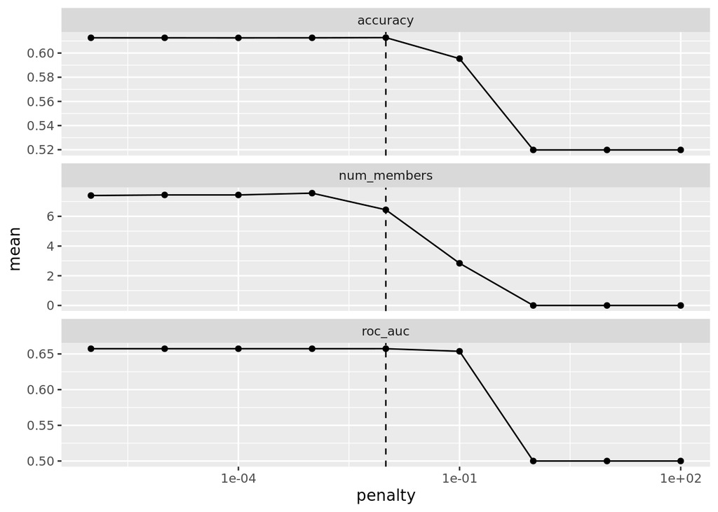

```r
autoplot(mimic_model_st)
```

To show the relationship more directly:

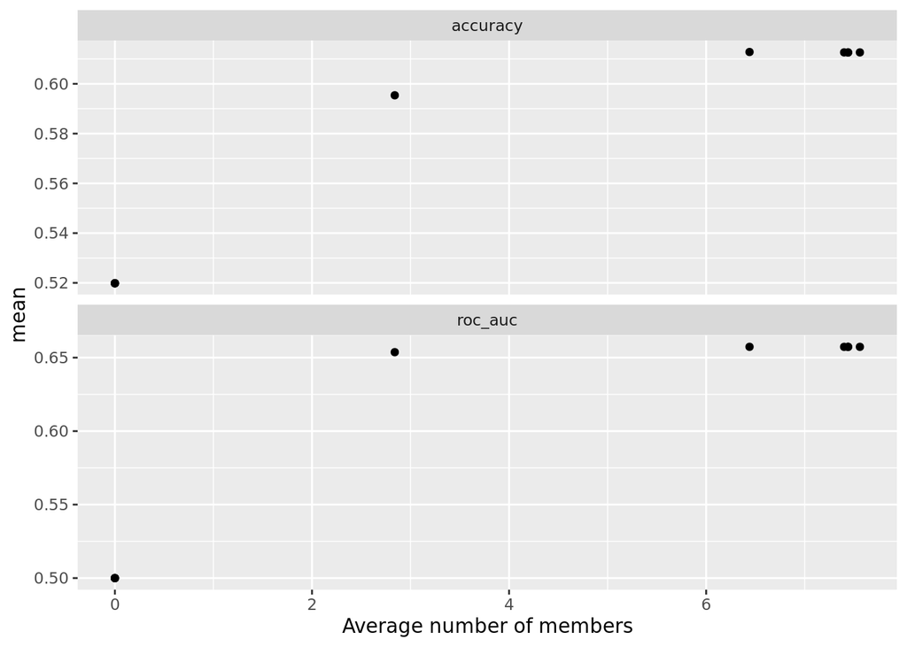

```r
autoplot(mimic_model_st, type = "members")
```

To see the top results:

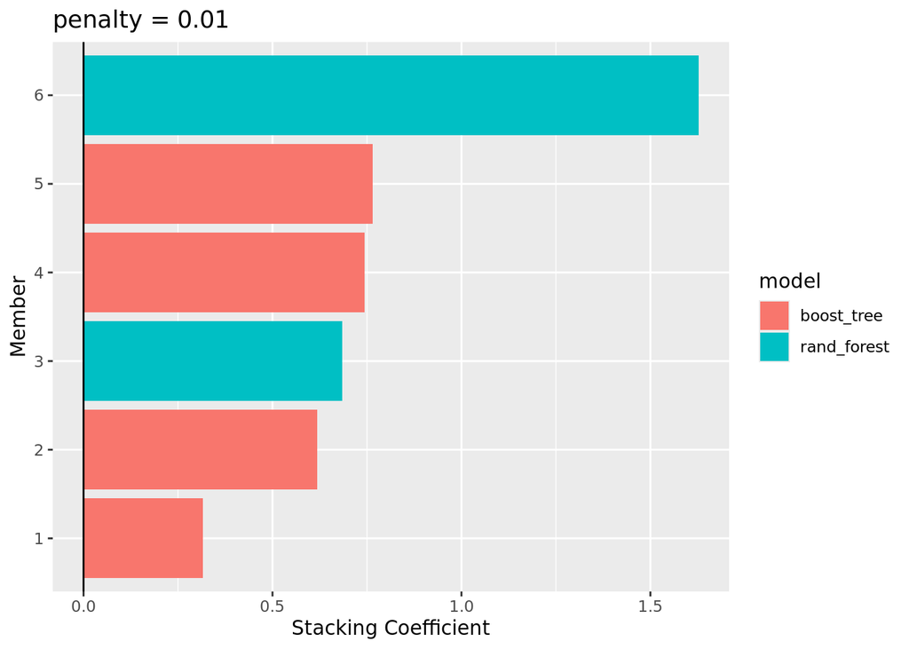

```r
autoplot(mimic_model_st, type = "weights")
```

To identify which model configurations were assigned what stacking coefficients, we can make use of the `collect_parameters()` function:

```r
collect_parameters(mimic_model_st, "rf_res")
```

```
# A tibble: 9 × 5
  member      mtry trees terms                  coef
  <chr>      <int> <int> <chr>                 <dbl>
1 rf_res_1_1     1  1000 .pred_TRUE_rf_res_1_1 0
2 rf_res_1_2     1  1500 .pred_TRUE_rf_res_1_2 0
3 rf_res_1_3     1  2000 .pred_TRUE_rf_res_1_3 0
4 rf_res_1_4     2  1000 .pred_TRUE_rf_res_1_4 0
5 rf_res_1_5     2  1500 .pred_TRUE_rf_res_1_5 0
6 rf_res_1_6     2  2000 .pred_TRUE_rf_res_1_6 0
7 rf_res_1_7     3  1000 .pred_TRUE_rf_res_1_7 0
8 rf_res_1_8     3  1500 .pred_TRUE_rf_res_1_8 1.63
9 rf_res_1_9     3  2000 .pred_TRUE_rf_res_1_9 0.684
```

## Final classification

```r
mimic_pred <- mimic_test %>%
  bind_cols(predict(mimic_model_st, ., type = "prob")) %>%
  print(width = Inf)
```

```
# A tibble: 36,591 × 25
   first_careunit                                   admission_type
   <fct>                                            <fct>
 1 Medical Intensive Care Unit (MICU)               EW EMER.
 2 Surgical Intensive Care Unit (SICU)              EW EMER.
 3 Surgical Intensive Care Unit (SICU)              Other
 4 Medical/Surgical Intensive Care Unit (MICU/SICU) EW EMER.
 5 Cardiac Vascular Intensive Care Unit (CVICU)     SURGICAL SAME DAY ADMISSION
 6 Other                                            EW EMER.
 7 Medical Intensive Care Unit (MICU)               EW EMER.
 8 Medical Intensive Care Unit (MICU)               EW EMER.
 9 Other                                            URGENT
10 Other                                            URGENT
   admission_location     insurance language marital_status race  gender
   <fct>                  <chr>     <chr>    <chr>          <fct> <chr>
```

[output cut: 71 more lines]

Computing the ROC AUC for the model:

```r
yardstick::roc_auc(
  mimic_pred,
  truth = los_long,
  contains(".pred_FALSE")
  )
```

```
# A tibble: 1 × 3
  .metric .estimator .estimate
  <chr>   <chr>          <dbl>
1 roc_auc binary         0.655
```

We can use the members argument to generate predictions from each of the ensemble members.

```r
mimic_pred <-
  mimic_test |>
  select(los_long) |>
  bind_cols(
    predict(
      mimic_model_st,
      mimic_test,
      type = "class",
      members = TRUE
      )
    ) |>
  print(width = Inf)
```

```
# A tibble: 36,591 × 8
   los_long .pred_class .pred_class_rf_res_1_8 .pred_class_rf_res_1_9
   <fct>    <fct>       <fct>                  <fct>
 1 FALSE    FALSE       FALSE                  FALSE
 2 FALSE    FALSE       TRUE                   TRUE
 3 FALSE    FALSE       FALSE                  FALSE
 4 FALSE    FALSE       FALSE                  FALSE
 5 FALSE    FALSE       FALSE                  FALSE
 6 TRUE     FALSE       FALSE                  FALSE
 7 TRUE     TRUE        TRUE                   TRUE
 8 TRUE     TRUE        TRUE                   TRUE
 9 TRUE     TRUE        TRUE                   TRUE
10 TRUE     TRUE        TRUE                   TRUE
   .pred_class_gb_res_1_10 .pred_class_gb_res_1_11 .pred_class_gb_res_1_09
   <fct>                   <fct>                   <fct>
```

[output cut: 23 more lines]

```r
map(
  colnames(mimic_pred),
  ~mean(mimic_pred$los_long == pull(mimic_pred, .x))
  ) |>
  set_names(colnames(mimic_pred)) |>
  as_tibble() |>
  pivot_longer(c(everything(), -los_long))
```

```
# A tibble: 7 × 3
  los_long name                    value
     <dbl> <chr>                   <dbl>
1        1 .pred_class             0.611
2        1 .pred_class_rf_res_1_8  0.604
3        1 .pred_class_rf_res_1_9  0.605
4        1 .pred_class_gb_res_1_10 0.599
5        1 .pred_class_gb_res_1_11 0.606
6        1 .pred_class_gb_res_1_09 0.609
7        1 .pred_class_gb_res_1_12 0.602
```